# Visualizing Correlations Recitation Solutions

You

10/4/2022

## Introduction

We will be using some data collection from the [National Health and Nutrition Examination Survey](https://www.cdc.gov/nchs/nhanes/index.htm) which collects data to assess the health and nutritional status of people in the United States. The data from 2009-2012 has been compiled in an R package called `NHANES`.

```r
# install.packages("NHANES")
library(NHANES)

# functionality and correlation packages
library(tidyverse)
library(corrplot)
library(ggcorrplot)
library(GGally)
library(Hmisc)
library(reshape2)
library(scales)

knitr::kable(head(NHANES))
```

| ID | SurveyYr | Gender | Age | AgeDecade | AgeMonths | Race1 | Race3 | Education | MaritalStatus | HHIncome | HHIncomeMid | Poverty | HomeRooms | HomeOwn | Work | Weight | Length | HeadCirc | Height | BMI | BMICatUnder20yrs | BMI_WHO | Pulse | BPSysAve | BPDiaAve | BPSys1 | BPDia1 | BPSys2 | BPDia2 | … |
| --- | --- | --- | --- | --- | --- | --- | --- | --- | --- | --- | --- | --- | --- | --- | --- | --- | --- | --- | --- | --- | --- | --- | --- | --- | --- | --- | --- | --- | --- | --- |
| 51624 | 2009_10 | male | 34 | 30-39 | 409 | White | NA | High School | Married | 25000-34999 | 30000 | 1.36 | 6 | Own | NotWorking | 87.4 | NA | NA | 164.7 | 32.22 | NA | 30.0_plus | 70 | 113 | 85 | 114 | 88 | 114 | 88 | … |
| 51624 | 2009_10 | male | 34 | 30-39 | 409 | White | NA | High School | Married | 25000-34999 | 30000 | 1.36 | 6 | Own | NotWorking | 87.4 | NA | NA | 164.7 | 32.22 | NA | 30.0_plus | 70 | 113 | 85 | 114 | 88 | 114 | 88 | … |
| 51624 | 2009_10 | male | 34 | 30-39 | 409 | White | NA | High School | Married | 25000-34999 | 30000 | 1.36 | 6 | Own | NotWorking | 87.4 | NA | NA | 164.7 | 32.22 | NA | 30.0_plus | 70 | 113 | 85 | 114 | 88 | 114 | 88 | … |
| 51625 | 2009_10 | male | 4 | 0-9 | 49 | Other | NA | NA | NA | 20000-24999 | 22500 | 1.07 | 9 | Own | NA | 17.0 | NA | NA | 105.4 | 15.30 | NA | 12.0_18.5 | NA | NA | NA | NA | NA | NA | NA | … |
| 51630 | 2009_10 | female | 49 | 40-49 | 596 | White | NA | Some College | LivePartner | 35000-44999 | 40000 | 1.91 | 5 | Rent | NotWorking | 86.7 | NA | NA | 168.4 | 30.57 | NA | 30.0_plus | 86 | 112 | 75 | 118 | 82 | 108 | 74 | … |
| 51638 | 2009_10 | male | 9 | 0-9 | 115 | White | NA | NA | NA | 75000-99999 | 87500 | 1.84 | 6 | Rent | NA | 29.8 | NA | NA | 133.1 | 16.82 | NA | 12.0_18.5 | 82 | 86 | 47 | 84 | 50 | 84 | 50 | … |

```r
NHANES_trimmed <- NHANES %>%
  select(Age, BMI, Pulse, starts_with("BP"), TotChol) %>%
  drop_na()

NHANES_cor <- cor(NHANES_trimmed)
```

## 1. How correlated are different measures of blood pressure?

In the NHANES dataset, there are 3 measurements for each systolic (the first/top number) and diastolic blood (the second/bottom number) pressure. How reproducible is each type of blood pressure measurement over the 3 samplings? Make visualizations to convey your findings.

### Wrangling, creating two dataframes

1. Includes the 4 measures for systolic BP `BPSysAve`, `BPSys1`, `BPSys2`, `BPSys3`
2. Includes the 4 measures for diastolic BP `BPDiaAve`, `BPDia1`, `BPDia2`, `BPDia3`

```r
# create df with all of the BP measurements
# remove missing values
NHANES_BP <- NHANES %>%
  select(starts_with("BP")) %>%
  drop_na()

# create df with all systolic data
NHANES_systolic <- NHANES_BP %>%
  select(contains("Sys"))

# create df with all diastolic data
NHANES_diastolic <- NHANES_BP %>%
  select(contains("Dia"))
```

### Run correlation analysis with `cor()` and `rcorr()`

```r
# run systolic correlation analysis
NHANES_sys_cor <- cor(NHANES_systolic)

# could also use rcorr()
NHANES_sys_rcorr <- rcorr(as.matrix(NHANES_systolic))

# run diastolic correlation analysis
NHANES_dia_cor <- cor(NHANES_diastolic)

# could also use rcorr()
NHANES_dia_rcorr <- rcorr(as.matrix(NHANES_diastolic))
```

### Prepare to plot with `corrplot()`

```r
# create a vector of the systolic names for labeling
sys_labels <- c("Systolic BP, Average",
                "Systolic BP 1",
                "Systolic BP 2",
                "Systolic BP 3")

dia_labels <- c("Diastolic BP, Average",
                "Diastolic BP 1",
                "Diastolic BP 2",
                "Diastolic BP 3")

# change row and column names of the correlation matrix
# so they are how we want them to be plotted
colnames(NHANES_sys_rcorr$r) <- sys_labels
rownames(NHANES_sys_rcorr$r) <- sys_labels
colnames(NHANES_dia_rcorr$r) <- dia_labels
rownames(NHANES_dia_rcorr$r) <- dia_labels

# change row and column names of the pvalue matrix
# so they are how we want them to be plotted
colnames(NHANES_sys_rcorr$P) <- sys_labels
rownames(NHANES_sys_rcorr$P) <- sys_labels
colnames(NHANES_dia_rcorr$P) <- dia_labels
rownames(NHANES_dia_rcorr$P) <- dia_labels
```

Plot

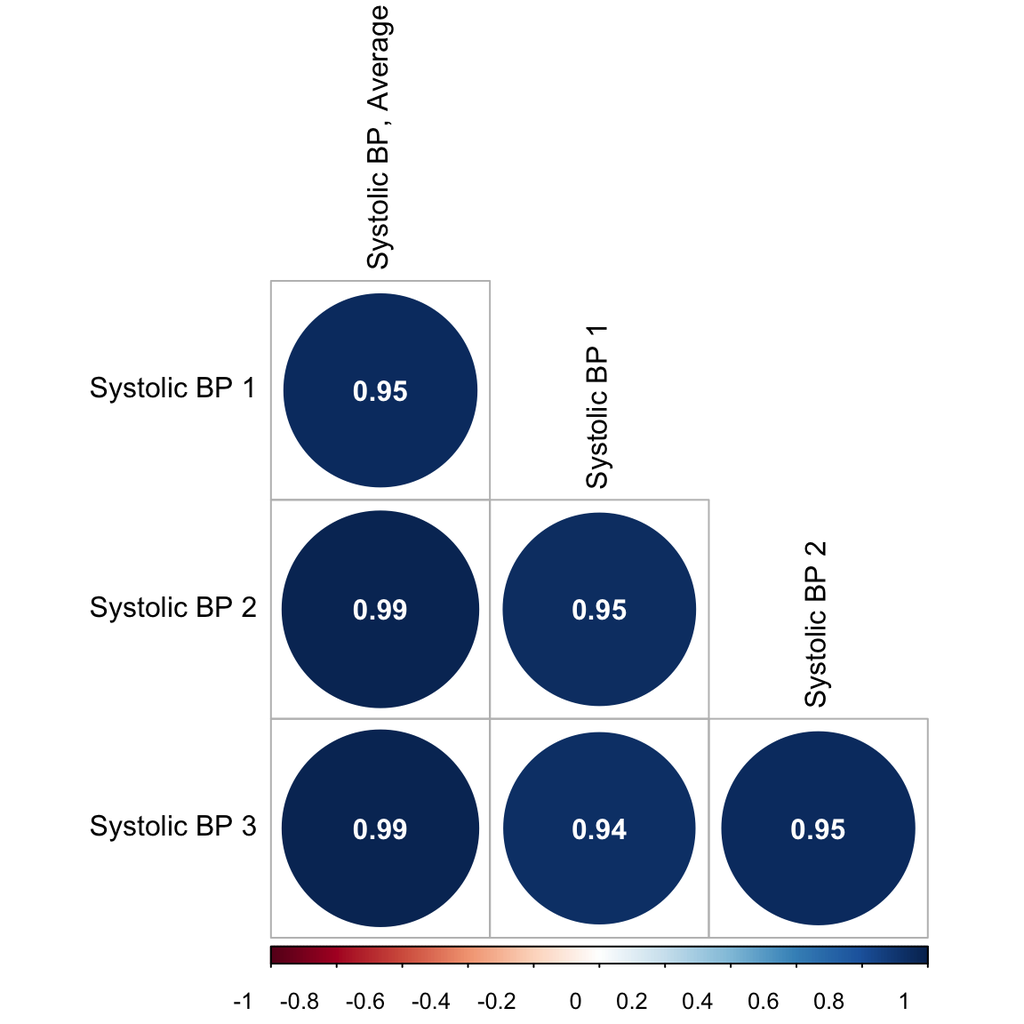

```r
corrplot(NHANES_sys_rcorr$r, # the correlation matrix
         type = "lower", # lower triangle
         tl.col = "black", # axis labels are black
         p.mat  = NHANES_sys_rcorr$P, # pvalue matrix
         sig.level = 0.05, # how sig does a cor need to be to be included
         insig = "blank", # do not display insignificant correlations
         addCoef.col = "white", # display correlations in black
         diag = FALSE, # don't show the diagonal (because this is all 1)
         number.cex = 1.0) # size of correlation font
```

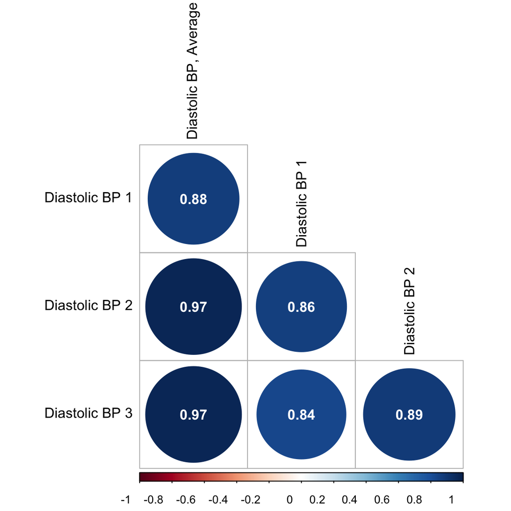

```r
corrplot(NHANES_dia_rcorr$r, # the correlation matrix
         type = "lower", # lower triangle
         tl.col = "black", # axis labels are black
         p.mat  = NHANES_dia_rcorr$P, # pvalue matrix
         sig.level = 0.05, # how sig does a cor need to be to be included
         insig = "blank", # do not display insignificant correlations
         addCoef.col = "white", # display correlations in black
         diag = FALSE, # don't show the diagonal (because this is all 1)
         number.cex = 1.0) # size of correlation font
```

### Prepare to plot with `melt()` and `ggplot()`

Create a lower triangle object to plot.

```r
# "save as"
sys_lower <- NHANES_sys_cor
dia_lower <- NHANES_dia_cor

# use function upper.tri() and set the upper triangle all to NA
# then we can keep only the lower triangle
sys_lower[upper.tri(sys_lower)] <- NA
dia_lower[upper.tri(dia_lower)] <- NA

# melt to go back to long format
melted_sys_lower <- melt(sys_lower, na.rm = TRUE)
melted_dia_lower <- melt(dia_lower, na.rm = TRUE)

# did it work?
head(melted_sys_lower)
```

```
##       Var1     Var2     value
## 1 BPSysAve BPSysAve 1.0000000
## 2   BPSys1 BPSysAve 0.9526899
## 3   BPSys2 BPSysAve 0.9881045
## 4   BPSys3 BPSysAve 0.9876269
## 6   BPSys1   BPSys1 1.0000000
## 7   BPSys2   BPSys1 0.9468706
```

```r
head(melted_dia_lower)
```

```
##       Var1     Var2     value
## 1 BPDiaAve BPDiaAve 1.0000000
## 2   BPDia1 BPDiaAve 0.8762961
## 3   BPDia2 BPDiaAve 0.9706381
## 4   BPDia3 BPDiaAve 0.9726614
## 6   BPDia1   BPDia1 1.0000000
## 7   BPDia2   BPDia1 0.8638015
```

Plot systolic

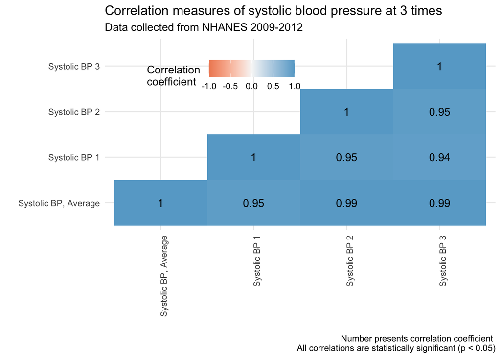

```r
# create a vector of the systolic names for labeling
sys_labels <- c("Systolic BP, Average",
                "Systolic BP 1",
                "Systolic BP 2",
                "Systolic BP 3")

melted_sys_lower %>%
  ggplot(aes(x = Var1, y = Var2, fill = value)) +
  geom_tile() +
  geom_text(aes(label = round(value, 2)), color = "black") +
  scale_fill_gradient2(low = "#ef8a62",
                       mid = "#f7f7f7",
                       high = "#67a9cf",
                       limits = c(-1, 1)) +
  scale_x_discrete(labels = sys_labels) +
  scale_y_discrete(labels = sys_labels) +
  theme_minimal() +
  theme(axis.text.x = element_text(angle = 90, hjust = 1),
        legend.justification = c(1, 0),
        legend.position = c(0.5, 0.7),
        legend.direction = "horizontal") +
  labs(fill = "Correlation \ncoefficient",
       x = "",
       y ="",
       title = "Correlation measures of systolic blood pressure at 3 times",
       subtitle = "Data collected from NHANES 2009-2012",
       caption = "Number presents correlation coefficient \nAll correlations are statistically significant (p < 0.05)")
```

Plot diastolic

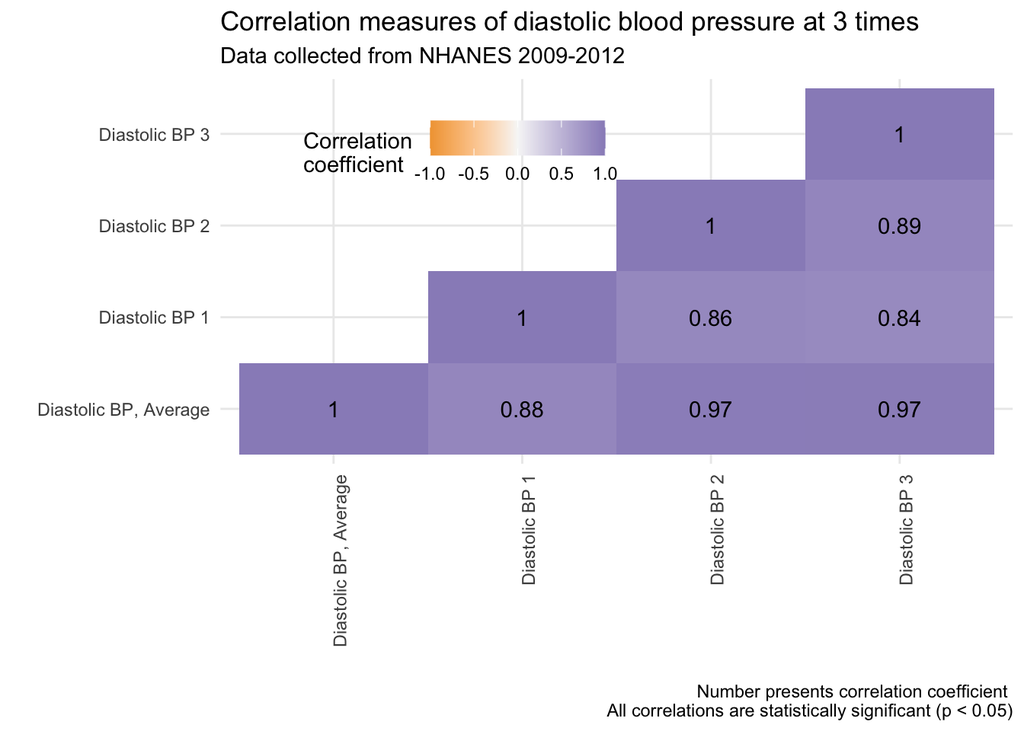

```r
# create a vector of the systolic names for labeling
dia_labels <- c("Diastolic BP, Average",
                "Diastolic BP 1",
                "Diastolic BP 2",
                "Diastolic BP 3")

melted_dia_lower %>%
  ggplot(aes(x = Var1, y = Var2, fill = value)) +
  geom_tile() +
  geom_text(aes(label = round(value, 2)), color = "black") +
  scale_fill_gradient2(low = "#f1a340",
                       mid = "#f7f7f7",
                       high = "#998ec3",
                       limits = c(-1, 1)) +
  scale_x_discrete(labels = dia_labels) +
  scale_y_discrete(labels = dia_labels) +
  theme_minimal() +
  theme(axis.text.x = element_text(angle = 90, hjust = 1),
        legend.justification = c(1, 0),
        legend.position = c(0.5, 0.7),
        legend.direction = "horizontal") +
  labs(fill = "Correlation \ncoefficient",
       x = "",
       y ="",
       title = "Correlation measures of diastolic blood pressure at 3 times",
       subtitle = "Data collected from NHANES 2009-2012",
       caption = "Number presents correlation coefficient \nAll correlations are statistically significant (p < 0.05)")
```

## 2. How correlated are different physical measurements, health, and lifestyle variables?

In the NHANES dataset, there are data for subject `BMI`, `Pulse`, `BPSysAve`, `BPDiaAve`, `TotalChol`.

Create a series of plots to show the relationship between these variables with each other.

```r
nhanes_trimmed <- NHANES %>%
  select(BMI, Pulse, BPSysAve, BPDiaAve, TotChol) %>%
  drop_na()
```

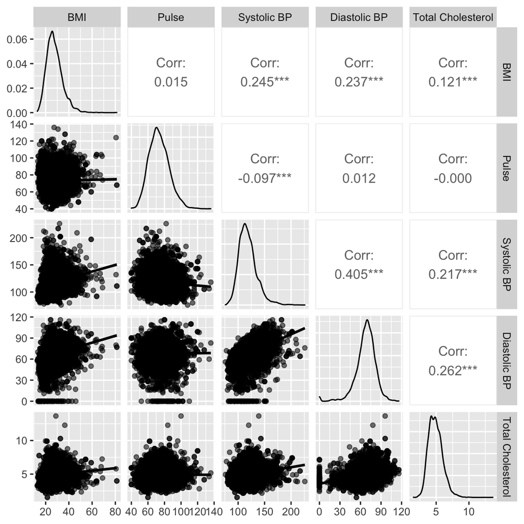

```r
nhanes_trimmed %>%
    ggpairs(columns = 1:5,
          aes(alpha = 0.01), # note alpha inside aes which is weird idk why
          lower = list(continuous = "smooth"),
          columnLabels = c("BMI", "Pulse", "Systolic BP", "Diastolic BP", "Total Cholesterol"))
```